# BMA_info

Joe Brown

2023-03-09

# Bayessian Model Averaging Background

It is often the case that multiple variable predictiona are made from an ensemble of climate models. Bayesian methods can be used to understand models that explain the relationship between predicted variables and observed data ([Hinne et al. 2020](https://journals.sagepub.com/doi/pdf/10.1177/2515245919898657)). Bayesian model selection is the process by which a posterior model probability (PMP) is computed and used to identify the probability of a model given observed data (Hinne et al. 2020).

**Bayesian model averaging** (BMA) can be used to summarize results when a large number of predictors are being considered. BMA estimates models for all possible combinations of explanatory variables (in our case model results) and constructs a weighted average over each ([BMA package](https://cran.r-project.org/web/packages/BMS/vignettes/bmsmanual.pdf)). A Bayesian model average is defined as a prediction of new observations obtained by averaging the predictions of different candidate models, each of which weighted by its model probability (Hinne et al. 2020). Inclusion probabilities are an example of a summarization method used in BMA (Hinne et al. 2020).

*In the context of climate models*: BMA has been described as a regression-based approach where the dependent variable is the observed climate variable of interest, and covariates are the outputs of a model ensemble ([Khan et al. 2021](https://link.springer.com/article/10.1007/s10651-021-00490-8)).

**Posterior inclusion probability** (PIP) can be defined as the model-averaged probability of including a certain predictor in the model given observations. This serves as an indicator of of how relevant a predictor is across all possible models (Hinne et al. 2020).

*In the context of climate models*: PIP is used as a model selection criterion, where PIP is the sum of the PMPs of each covariate contribution from all possible regression models included in BMA (Kahn et al. 2021). Culka ([2016](https://energsustainsoc.biomedcentral.com/articles/10.1186/s13705-016-0073-0#Sec1)) explains that PIP can be seen as the quality of a covariate in explaining the observed data with respect to all other covariates included in the analysis.

The PIP has a range from 0-1, where a value close to 1 means that the corresponding candidate model (i.e., covariate) is a good contributor to explaining the variability in the observed data. Values close to 0 mean the corresponding candidate model does not contribute to explaining the variability (Khan et al. 2021).

In other non-climate or energy system studies, PIP have offered an intuitive and convenient aid to subset model selection. For example, a subset selection can be made based on PIPs of covariates by setting a threshold value (Morozova et al. 2015).

# The [BMS package](https://cran.r-project.org/web/packages/BMS/BMS.pdf)

As stated prior, estimates models for all possible combinations of explanatory variables (in our case model results) and constructs a weighted average over all of them. If a data frame contains K potential covariates (model outputs), this means estimating 2<sup>*K*</sup> model combinations (i think). More on defaults are below before running the model. The model selection process using BMA is completed using `bms()`. The following steps shows how to perform BMA with a simple data set and how to obtain posterior coefficients and model stats.

## Examples:

### Example one

This example uses sample data produced to have 3 models that don’t follow the observed data well and one that is exactly identical (mod4).

Start by building a simple data frame. Here, I created a data frame with 4 covariates (which represent separate runs from an `iterate_hector` output). The observed data are stored in the first column of the data frame. The function `bms` assumes that first column is the response variable (observed data). Notice that a random distribution of values are produced for models 1-3, model 4 is identical to the observed data to force a result with a high PIP for this model.

```r
library(BMS)

set.seed(0)
data <- data.frame(
  observed = c(333, 350, 360, 400, 402, 418, 499, 508, 510, 520),
  mod1 = rnorm(10, mean = 550, sd = 100),
  mod2 = rnorm(10, mean = 450, sd = 100),
  mod3 = rnorm(10, mean = 450, sd = 100),
  mod4 = c(333, 350, 360, 400, 402, 418, 499, 508, 510, 520))

head(data)
```

```
##   observed     mod1     mod2     mod3 mod4
## 1      333 676.2954 526.3593 427.5732  333
## 2      350 517.3767 370.0991 487.7396  350
## 3      360 682.9799 335.2343 463.3336  360
## 4      400 677.2429 421.0538 530.4190  400
## 5      402 591.4641 420.0785 444.2893  402
## 6      418 396.0050 408.8489 500.3608  418
```

Performing the model sampling using `bms`.

```r
bmao <- bms(data,
    mprior = "uniform",
    g = "UIP",
    user.int = F)
```

For the sake of simplicity in this example, I set `mprior = "uniform"` which informs the function to assign a uniform model prior. The unit information prior (`UIP`) is set for Zellners g (`g`) – still reading about this and its importance as the variance structure of prior coefficients. However, a popular default is to set *g* = *N*. Thus it gives about the same information to the prior as is contained in one observation. It is important to note there are a number of options for setting `g`, there is more information regarding this in the [package vignette](https://cran.r-project.org/web/packages/BMS/vignettes/bmsmanual.pdf)). There is also a summary in this paper by [Amini and Parmeter 2020](https://www.mdpi.com/2225-1146/8/1/6).

### Coefficient Results

```r
coef(bmao)
```

```
##            PIP     Post Mean    Post SD Cond.Pos.Sign Idx
## mod4 0.9999239  9.090217e-01 0.11027518    1.00000000   4
## mod3 0.2316674 -5.987425e-06 0.05723776    0.05366229   3
## mod1 0.2316636 -1.393247e-06 0.03225747    0.05366317   1
## mod2 0.2316631 -1.832995e-06 0.05705130    0.05366327   2
```

### Example 2

This example uses sample data produced to have 2 models that are close to the observed data and 2 that are off. This is a test to compare with Example 1 to see how they differ.

The code is similar to above with the exception of the data.

```r
library(tibble)

# for some reason this does not work...when passing to bms()
data3tib <- tibble(
  observed = c(333, 350, 360, 400, 402, 418, 499, 508, 510, 520),
  mod1 = observed + 2,
  mod2 = observed + 16,
  mod3 = observed - 16,
  mod4 = observed - 4)

data3 <- data.frame(
  observed = c(333, 350, 360, 400, 402, 418, 499, 508, 510, 520),
  mod1 = c(330, 347, 355, 397, 398, 416, 496, 505, 508, 517),
  mod2 = c(223, 240, 250, 390, 392, 408, 488, 498, 550, 610),
  mod3 = c(336, 353, 363, 403, 405, 421, 502, 511, 513, 523),
  mod4 = c(345, 463, 472, 511, 510, 525, 597, 615, 618, 623))

head(data3)
```

```
##   observed mod1 mod2 mod3 mod4
## 1      333  330  223  336  345
## 2      350  347  240  353  463
## 3      360  355  250  363  472
## 4      400  397  390  403  511
## 5      402  398  392  405  510
## 6      418  416  408  421  525
```

```r
bmao2 <- bms(data3,
             mprior = "uniform", user.int = F)
```

```r
coeff <- coef(bmao2, condi.coefs = T)

print(coeff)
```

```
##            PIP  Post Mean   Post SD Cond.Pos.Sign Idx
## mod3 0.5387221 0.48974738 3.6100322     1.0000000   3
## mod1 0.5365801 0.37222473 3.5897251     0.8212945   1
## mod2 0.2594096 0.01602312 0.1390039     0.1769441   2
## mod4 0.2441671 0.01177348 0.1568220     0.4888677   4
```

What are the posterior model probabilities:

```r
# what are the top models
topmodels.bma(bmao2)
```

```
##                   02       08       06       03       0a       09       0c
## mod1           0.000    1.000   0.0000   0.0000   1.0000   1.0000   1.0000
## mod2           0.000    0.000   1.0000   0.0000   0.0000   0.0000   1.0000
## mod3           1.000    0.000   1.0000   1.0000   1.0000   0.0000   0.0000
## mod4           0.000    0.000   0.0000   1.0000   0.0000   1.0000   0.0000
## PMP (Exact) 1078.687 1072.947 325.2363 325.2363 325.2363 323.6615 323.5499
## PMP (MCMC)  1078.687 1072.947 325.2363 325.2363 325.2363 323.6615 323.5499
##                  04       0e       07       0b       0d       05       01
## mod1          0.000  1.00000  0.00000  1.00000  1.00000  0.00000  0.00000
## mod2          1.000  1.00000  1.00000  0.00000  1.00000  1.00000  0.00000
## mod3          0.000  1.00000  1.00000  1.00000  0.00000  0.00000  0.00000
## mod4          0.000  0.00000  1.00000  1.00000  1.00000  1.00000  1.00000
## PMP (Exact) 112.777 98.06243 98.06243 98.06243 97.60728 60.28264 45.37847
## PMP (MCMC)  112.777 98.06243 98.06243 98.06243 97.60728 60.28264 45.37847
##                   0f         00
## mod1         1.00000 0.00000000
## mod2         1.00000 0.00000000
## mod3         1.00000 0.00000000
## mod4         1.00000 0.00000000
## PMP (Exact) 29.56693 0.07367575
## PMP (MCMC)  29.56693 0.07367575
```

```r
# what are the PMPs for all models
pmp.bma(bmao2, oldstyle = T)
```

```
##     PMP (Exact)   PMP (MCMC)
## 02 2.443548e-01 1.078687e+03
## 08 2.430547e-01 1.072947e+03
## 06 7.367575e-02 3.252363e+02
## 03 7.367575e-02 3.252363e+02
## 0a 7.367575e-02 3.252363e+02
## 09 7.331903e-02 3.236615e+02
## 0c 7.329374e-02 3.235499e+02
## 04 2.554737e-02 1.127770e+02
## 0e 2.221408e-02 9.806243e+01
## 07 2.221408e-02 9.806243e+01
## 0b 2.221408e-02 9.806243e+01
## 0d 2.211097e-02 9.760728e+01
## 05 1.365582e-02 6.028264e+01
## 01 1.027958e-02 4.537847e+01
## 0f 6.697796e-03 2.956693e+01
## 00 1.668976e-05 7.367575e-02
```

We can also pull out PMP values for individual models.

However the PMP value produced is a scalar of the posterior probabilities.

To use as a weighting value between 0-1, scalar needs to be normalized. This will produce a PMP equivalent to the tradtitional 0-1 values representing PMPs.

```r
# this is the PMP scalar for model 3 (top model)
mod3 <- pmpmodel(bmao2, model = "mod3")

sapply(rownames(coeff), function(m) {
  pmpmodel(bmao2, model = m)
})
```

```
##       mod3       mod1       mod2       mod4
## 1078.68671 1072.94729  112.77702   45.37847
```

```r
# this is a df of PMP scalar values from all models
PMPs <- data.frame(pmp.bma(bmao2))

# This is the normalized model 3 PMP
mod3 / sum(PMPs$PMP..Exact.)
```

```
## [1] 0.2443548
```

The following plots show the weighted average of the models when using PIPs as weights vs. PMPs as weights.

```r
library(ggplot2)
library(tidyverse)
# adding year column in data
data3$year <- 1990:1999

# convert long format to wide - tidy
PIP_long <- gather(data3, model, value, observed:mod4)

# separate df for observed data
observed <- data.frame(
  year = data3$year,
  value = data3$observed)

# separate df for model predictions - adding wts column (using either PIP or PMP as weights)
projected <- data.frame(
  subset(PIP_long, model != "observed") ,
  PIP_wts = rep(c(0.537, 0.259, 0.539, 0.244), each = 10),
  PMP_wts = rep(c(0.243, 0.026, 0.244,  0.01), each = 10))

# computing a weighted mean column to test how well it matches observed data
wt_projected <- projected %>%
  group_by(year) %>%
  mutate(PIP_wt_average = weighted.mean(value, PIP_wts)) %>%
  mutate(PMP_wt_average = weighted.mean(value, PMP_wts))
```

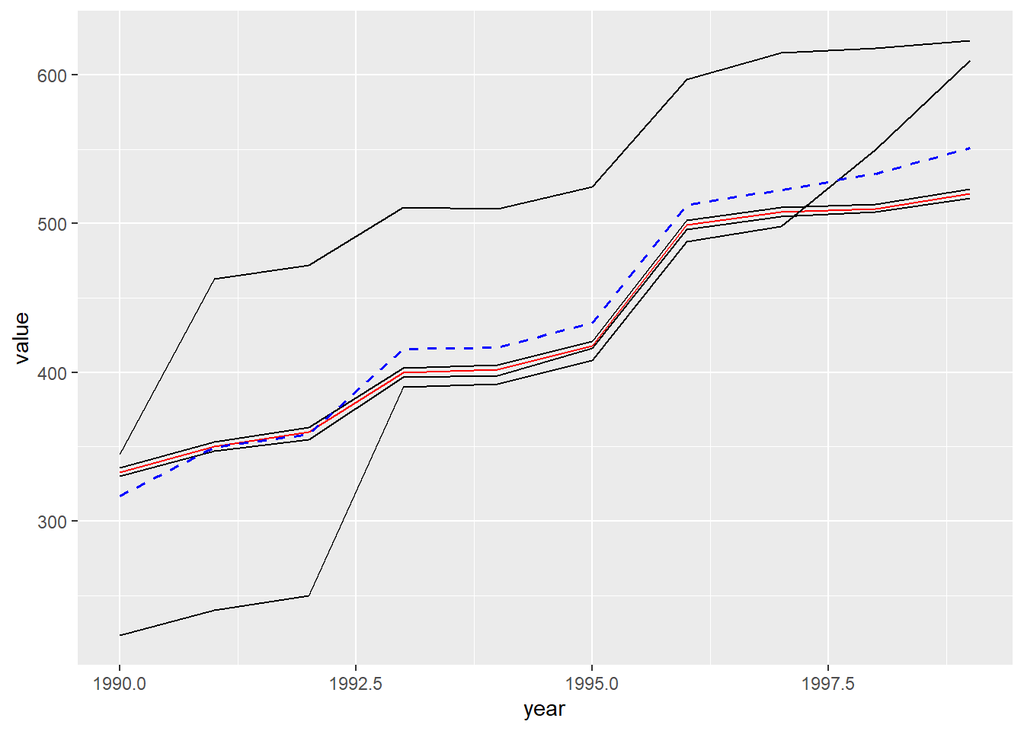

```r
# Try plotting the models against the observed data
observed <- ggplot(data = observed, aes(x = year, y = value)) +
  geom_line(color = "red")

PIP_wt <- observed +
  geom_line(data = projected, aes(x = year, y = value, group = model)) +
  geom_line(data = wt_projected, aes(x = year, y = PIP_wt_average),
            linetype = "dashed",
            color = "blue",
            linewidth = 0.7)
PIP_wt
```

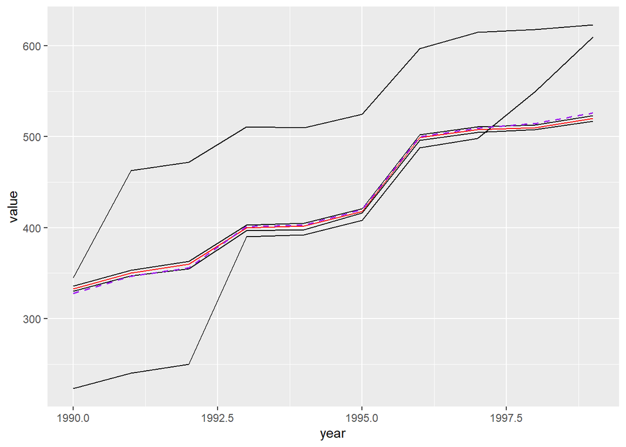

```r
PMP_wt <- observed +
  geom_line(data = projected, aes(x = year, y = value, group = model)) +
  geom_line(data = wt_projected, aes(x = year, y = PMP_wt_average),
            linetype = "dashed",
            color = "purple",
            linewidth = 0.7)
PMP_wt
```

The use of PMPs as weights produces a weighted average of the models included that is much more in line with observed values.

PIPs are still useful in determining how models rank and could be used as cutoff values for skilled vs. unskilled models, but shouldn’t be used as weights.

Using PMPs as weights is consistent with Min and Hense (2006) (and Raferty 2005, although I have not read through this). Min and Hense use bayes factors, which they explain is = PMP when priors are assumed identical, to compute weighted averages for Multi-model ensembles. They show that BMA results of models are closer to observed data than arithmetic ensemble mean.

# Example of using MCMC sample

Markov Chain Monte Carlo sampling is a method used when there are so many variables that enumerating all potential variable combinations is not feasible or too computationally expensive.

More covariates = More time intensive.

MCMC sampling helps with these issues by by gathering results from the most important part of the posterior model distribution. Here, I’m walking through the MCMC sampling solution for a large data set presented in the `BMS` package.

The default `mcmc` method is `bd`. This is the standard model sampler used in most BMA routines.

The quality of the MCMC approximation to the actual posterior distribution depends on the number of draws the MCMC sampler runs through. The first batch of iterations will typically not draw3 models with high PMPs. The sampler will only after a while converge on models with the largest marginal likelihood. the first set of iterations are omitted from the computation of results. In `bms()` this is indicated by the number of `burns`. The argument `iter` indicates the number of subsequent iterations to be retained.

In this example, the g-prior is set to `BRIC`: g = max(N, K<sup>2</sup>) and bridges g-UIP and g-RIC priors, depending on the values of K. – Not really sure hat this means yet, still trying to understand g-priors and the differences between each.

The number of top models saved is specified by `nmodel`.

```r
data(datafls)

fls1 <- bms(datafls,
            burn = 50000,
            iter = 100000,
            g = "BRIC",
            mprior = "Uniform",
            nmodel = 2000,
            mcmc = "bd",
            user.int = F
            )

summary(fls1)
```

```
## Mean no. regressors               Draws             Burnins                Time
##           "10.4938"             "1e+05"             "50000"     "4.872953 secs"
##  No. models visited      Modelspace 2^K           % visited         % Topmodels
##             "25638"           "2.2e+12"           "1.2e-06"                "43"
##            Corr PMP            No. Obs.         Model Prior             g-Prior
##            "0.9047"                "72"    "uniform / 20.5"              "BRIC"
##     Shrinkage-Stats
##         "Av=0.9994"
```

When we view the `summary` information of the bmao we can check the **convergence**. Convergence is the point at which the MCMC algorithm has run long enough to produce samples that are representative of the target posterior distribution. At this point, the samples generated can be used for inference like calculating model probabilities.

To assess the convergence between MCMC PMPs and analytical PMPs, we can inspect the correlation between MCMC and analytical PMPs by looking at `Corr PMP` in the summary. When this correlation is high, we can be confident that the samples are coming from the intended distribution. The lower this correlation, it is likely there is a lower the degree of convergence.

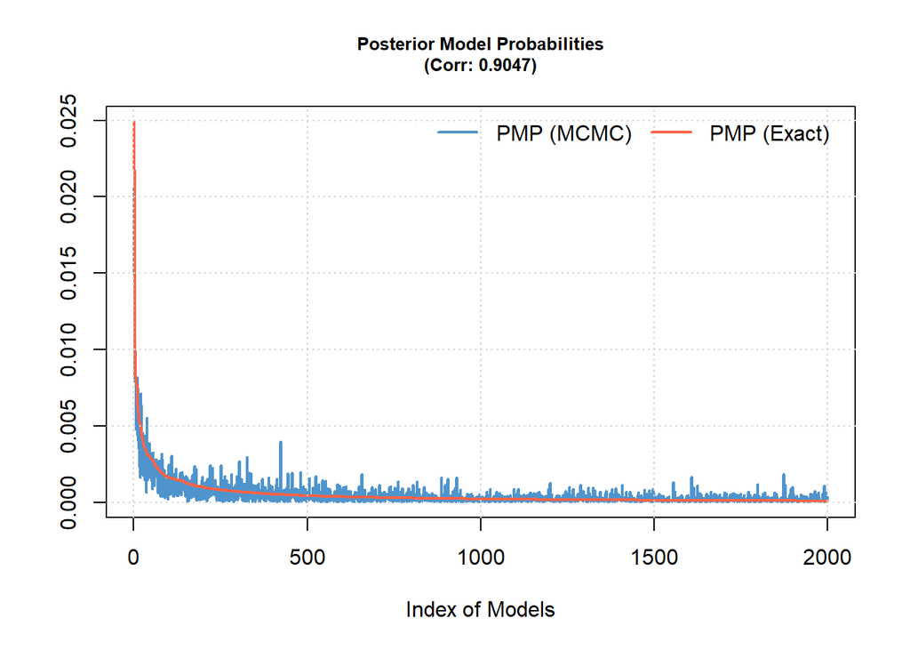

```r
plotConv(fls1)
```